# Reproducible Research: Peer Assesment1

Antonio

8 de abril de 2016

### 1.1 Load Data and preprocessing the data

```r
setwd("C:/Users/Antonio/R/C5")
datos<-read.csv("activity.csv")
summary(datos)
```

```
##      steps                date          interval
##  Min.   :  0.00   2012-10-01:  288   Min.   :   0.0
##  1st Qu.:  0.00   2012-10-02:  288   1st Qu.: 588.8
##  Median :  0.00   2012-10-03:  288   Median :1177.5
##  Mean   : 37.38   2012-10-04:  288   Mean   :1177.5
##  3rd Qu.: 12.00   2012-10-05:  288   3rd Qu.:1766.2
##  Max.   :806.00   2012-10-06:  288   Max.   :2355.0
##  NA's   :2304     (Other)   :15840
```

```r
datos$date<-as.Date(datos$date)
```

Find the % number of NA’s in data set

```r
mean(is.na(datos$steps))
```

```
## [1] 0.1311475
```

The number is high, we look for a pattern

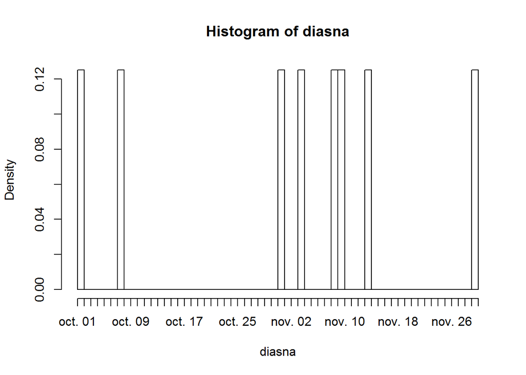

```r
steps<-datos$steps
nasteps<-is.na(steps)
dias<-datos$date
diasna<-dias[nasteps]
hist(diasna,"day")
```

The NA’s are concentrated in 8 sample days we see what day of the week to see if there is repetition, sequence, Maybe data missing every Tuesday? etc

```r
unique(sapply(dias[nasteps],weekdays))
```

```
## [1] "lunes"     "jueves"    "domingo"   "viernes"   "sábado"    "miércoles"
```

THe days of the week do not tell us much (not the same day of week, and from Histogram not same week)

### 2. What is mean total number of steps taken per day?

2.1 calculate total number of steps per day (NA eliminated) Histogram of Total Steps Per Day

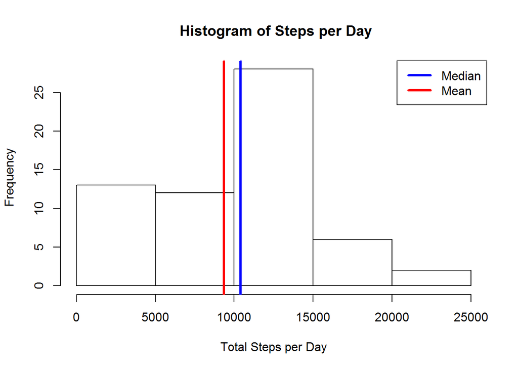

```r
totalstepsday<-with(datos,tapply(steps,date,sum,na.rm=TRUE))
hist(totalstepsday, main = " Histogram of Steps per Day",xlab = "Total Steps per Day")
abline(v=median(totalstepsday),lwd=3, col="Blue")
abline(v=mean(totalstepsday),lwd=3, col="red")
legend("topright",c("Median","Mean"),col = c("blue","red"),lwd = 3)
```

Boxplot of Total Steps per Day

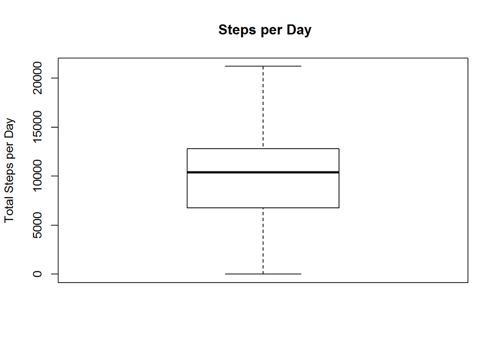

```r
boxplot(totalstepsday, main = " Steps per Day",ylab = "Total Steps per Day")
```

2.3 Calaculate and report the mean and median, mean of Total Steps per day and summary

```r
summary(totalstepsday)
```

```
##    Min. 1st Qu.  Median    Mean 3rd Qu.    Max.
##       0    6778   10400    9354   12810   21190
```

```r
print(median(totalstepsday))
```

```
## [1] 10395
```

```r
print(mean(totalstepsday))
```

```
## [1] 9354.23
```

### 3 What is the average daily activity pattern?

3.1 calculate and Plot the average for time intervals across different dates

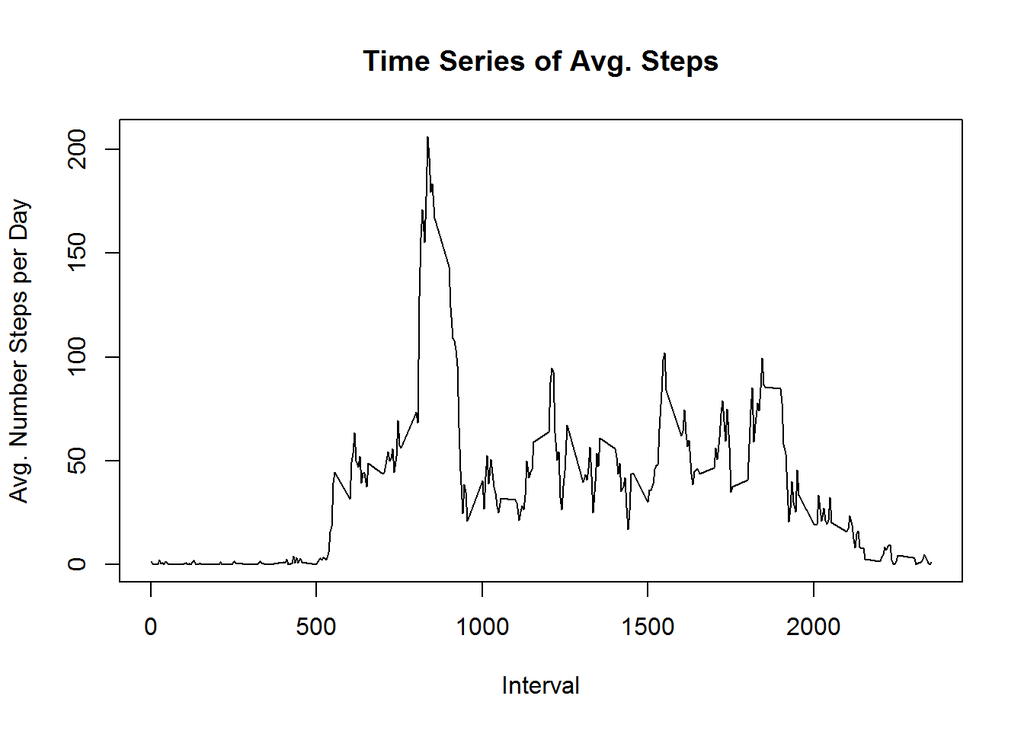

```r
avginterv<-with(datos,tapply(steps,interval,mean,na.rm=TRUE))
plot(names(avginterv),avginterv,type = "l",xlab = "Interval", ylab = "Avg. Number Steps per Day", main = "Time Series of Avg. Steps")
```

3.2 Find the 5-minute interval that contains the maximun (average) number of Steps

```r
print(names(which.max(avginterv)))
```

```
## [1] "835"
```

### 4 Imputing missing values

4.1 Calculate and report total number of missing values in dataset

```r
print(sum(is.na(datos$steps)))
```

```
## [1] 2304
```

4.2 Divise a stratgy for missing values in dataset

*4.2.1 I will use the average steps per interval calculated over the dataset days to fill in data

+I create a dataframe with the previously calulated data

+I create an variable holding the positions in which NA data appears

+I create a new dataset which is equal to original data

+Change values for NA in steps variable

```r
avgint<-data.frame(interval=names(avginterv),average=avginterv)
acambiar<-which(nasteps)
datos1<-data.frame(datos)
for (x in acambiar){
    y=datos$interval[x]
    datos1$steps[x]=avgint$average[avgint$interval==y]
}
```

4.4 Make a histogram of total steps taken each day and calculate and report media.

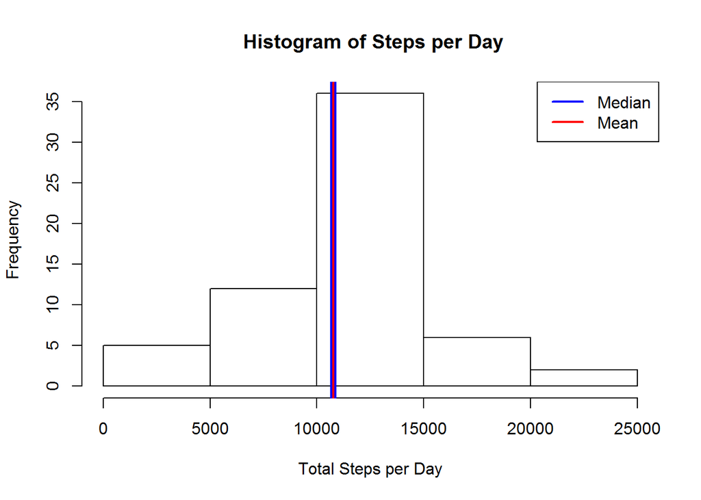

```r
totalstepsday1<-with(datos1,tapply(steps,date,sum,na.rm=TRUE))
hist(totalstepsday1, main = " Histogram of Steps per Day",xlab = "Total Steps per Day")
abline(v=median(totalstepsday1),lwd=6, col="Blue")
abline(v=mean(totalstepsday1),lwd=2, col="red")
legend("topright",c("Median","Mean"),col = c("blue","red"),lwd = 2)
```

And a Boxplot

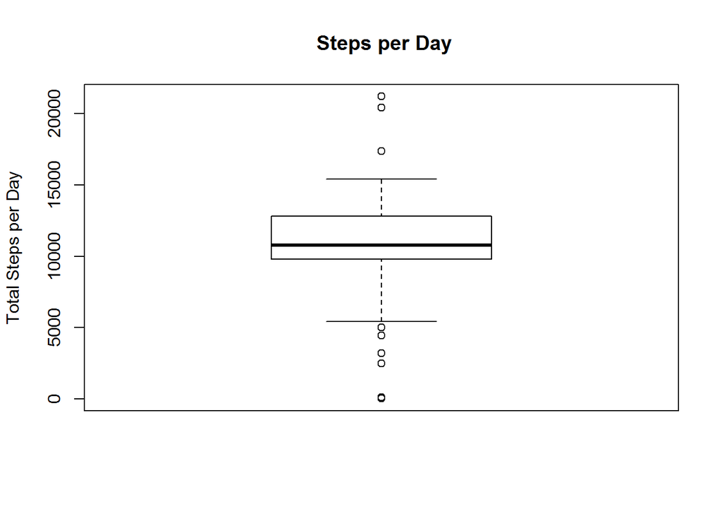

```r
boxplot(totalstepsday1, main = " Steps per Day",ylab = "Total Steps per Day")
```

Calculate and report the mean and median, mean of Total Steps per day and summary

```r
summary(totalstepsday1)
```

```
##    Min. 1st Qu.  Median    Mean 3rd Qu.    Max.
##      41    9819   10770   10770   12810   21190
```

```r
print(median(totalstepsday1))
```

```
## [1] 10766.19
```

```r
print(mean(totalstepsday1))
```

```
## [1] 10766.19
```

The main impact of using this method of filling data is that the median increases and is now equal to mean. The histogram ### appear to be more “gaussin-normal”

### 5 Are there differences in activity patterns between weekdays and weekends?

5.1 create a new factor variable with two levels - weekeday and weekend

```r
datos1$dayweek<-sapply(datos1$date,weekdays)
days<-unique(datos1$dayweek)
weekday<-days[0:5]
weekend<-days[6:7]
cambio<-function(x){
    if (x %in% weekday){
        x="Weekday"
    } else{
        x="Weekend"
    }
}
datos1$wow<-sapply(datos1$dayweek,cambio)
week<-subset(datos1,datos1$wow=="Weekday")
nweek<-subset(datos1,datos1$wow=="Weekend")
```

5.1 2. Make a panel plot containing a time series plot (i.e. type = “l”) of the 5-minute interval (x-axis) and the average number of steps taken, averaged across all weekday days or weekend days (y-axis).

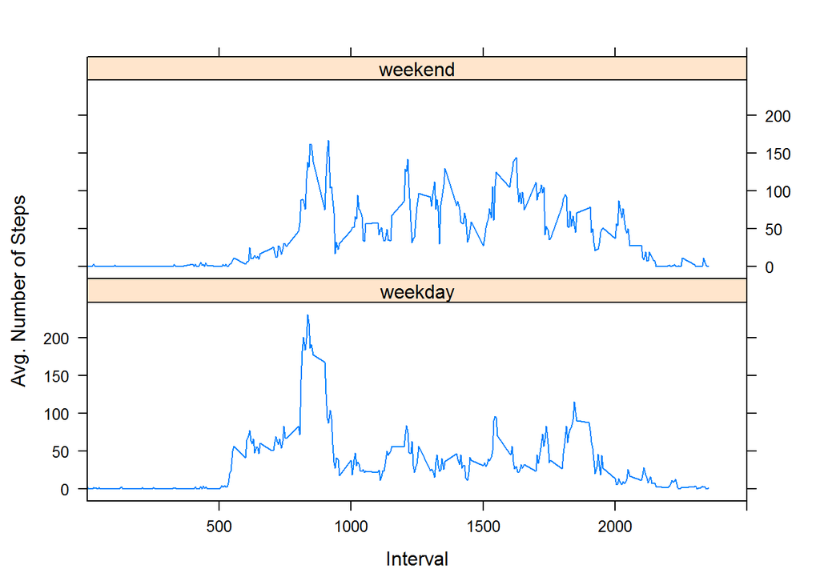

```r
avgweek<-with(week,tapply(steps,interval,mean))
avgweekend<-with(nweek,tapply(steps,interval,mean))
davgweek<-data.frame(Interval=as.numeric(names(avgweek)),average=as.numeric(avgweek))
davgweek$day<-"weekday"
davgweekend<-data.frame(Interval=as.numeric(names(avgweekend)),average=as.numeric(avgweekend))
davgweekend$day<-"weekend"
plotsdata<-rbind(davgweek,davgweekend)
library(lattice)
xyplot(average~Interval|day, data = plotsdata, layout=c(1,2), type="l", xlab = "Interval",ylab = "Avg. Number of Steps",xlim = c(0.500,1000,1500,2000,2500))
```